# Report

Willy Cass

January 17, 2015

# Predicting Weight-lifting Activity Class

First, we load the data. The data has been previously downloaded into the working directory using download.data.R (available on Github for inspection). The data is loaded and columns with missing data are excluded. These are summary columns, and we will be predicting based on single rows (which we need to do for the test set). The class of each row is then copied into a seperate variable. The columns for timestamp, name, and window are removed. The outcome, classe, is also removed. The predictors are now in `data3` with the outcome in `class`:

```r
library(lattice); library(ggplot2); library(caret); library(gbm)
set.seed(1234)
data <- read.csv('training.csv', na.strings = c('NA', ''))
class <- data$classe
NAcol <- sapply(data, anyNA)
data2 <- data[,!NAcol]
data3 <- data2[,-c(1,2,3,4,5,6,7,60)]
```

Then the training data is split into train and validate sets, using 80% of the data to train the dataset:

```r
trainIndex <- createDataPartition(class, p = .8, list = FALSE, times = 1)
train <- data3[trainIndex, ]
class.train <- class[trainIndex]
validate <- data3[-trainIndex, ]
class.validate <- class[-trainIndex]
```

Next we make sure all of the predictors have variance. None of the remaining predictors have near zero variance:

```r
nearZeroVar(train)
```

```
## integer(0)
```

Next we preprocess the predictors, centering, scaling, and performing principle component analysis:

```r
procRules <- preProcess(train, method = c('center', 'scale', 'pca'))
train2 <- predict(procRules, train)
validate2 <- predict(procRules, validate)
```

We create a prediction model with `gbm`. This method uses gradient boosting. The output is held for brevity. We plot the accuracy of the boosting iterations:

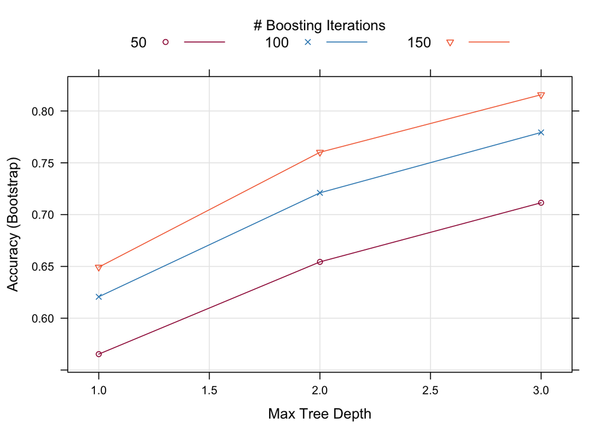

```r
fit <- train(train2, class.train, method = 'gbm')
trellis.par.set(caretTheme())
plot(fit)
```

Next, we compare the predictions from this model to the actual class from the data that it was trained on:

```r
cm1 <- confusionMatrix(class.train, predict(fit))
cm1
```

```
## Confusion Matrix and Statistics
##
##           Reference
## Prediction    A    B    C    D    E
##          A 4126   54  115  131   38
##          B  293 2384  248   50   63
##          C   98  179 2365   62   34
##          D   64   25  256 2190   38
##          E   63  151  194  106 2372
##
## Overall Statistics
##
##                Accuracy : 0.8559
##                  95% CI : (0.8503, 0.8614)
##     No Information Rate : 0.2958
##     P-Value [Acc > NIR] : < 2.2e-16
##
##                   Kappa : 0.8176
##  Mcnemar's Test P-Value : < 2.2e-16
##
## Statistics by Class:
##
##                      Class: A Class: B Class: C Class: D Class: E
## Sensitivity            0.8885   0.8536   0.7442   0.8625   0.9320
## Specificity            0.9694   0.9493   0.9702   0.9709   0.9609
## Pos Pred Value         0.9243   0.7847   0.8638   0.8511   0.8219
## Neg Pred Value         0.9539   0.9677   0.9373   0.9734   0.9865
## Prevalence             0.2958   0.1779   0.2024   0.1617   0.1621
## Detection Rate         0.2628   0.1519   0.1506   0.1395   0.1511
## Detection Prevalence   0.2843   0.1935   0.1744   0.1639   0.1838
## Balanced Accuracy      0.9289   0.9014   0.8572   0.9167   0.9465
```

And then to the 20% of the data we held in reserve for validation:

```r
cm1 <- confusionMatrix(class.validate, predict(fit, newdata = validate2))
cm1
```

```
## Confusion Matrix and Statistics
##
##           Reference
## Prediction    A    B    C    D    E
##          A 1008   17   42   38   11
##          B   97  547   64   20   31
##          C   35   73  543   28    5
##          D   18   14   72  518   21
##          E   27   56   43   25  570
##
## Overall Statistics
##
##                Accuracy : 0.8121
##                  95% CI : (0.7996, 0.8242)
##     No Information Rate : 0.3021
##     P-Value [Acc > NIR] : < 2.2e-16
##
##                   Kappa : 0.7619
##  Mcnemar's Test P-Value : < 2.2e-16
##
## Statistics by Class:
##
##                      Class: A Class: B Class: C Class: D Class: E
## Sensitivity            0.8506   0.7737   0.7107   0.8235   0.8934
## Specificity            0.9606   0.9341   0.9554   0.9621   0.9540
## Pos Pred Value         0.9032   0.7207   0.7939   0.8056   0.7906
## Neg Pred Value         0.9369   0.9494   0.9318   0.9662   0.9788
## Prevalence             0.3021   0.1802   0.1947   0.1603   0.1626
## Detection Rate         0.2569   0.1394   0.1384   0.1320   0.1453
## Detection Prevalence   0.2845   0.1935   0.1744   0.1639   0.1838
## Balanced Accuracy      0.9056   0.8539   0.8330   0.8928   0.9237
```

Finally we generate predictions for the 20 validation data points and generate individual files for each to be uploaded:

```r
source('pml_write_files.R') #function provided in instructions on course website
test <- read.csv('test.csv', na.strings = c('NA', ''))
NAcol.test <- sapply(test, anyNA)
test2 <- test[,!NAcol]
test3 <- test2[,-c(1,2,3,4,5,6,7,60)]
test4 <- predict(procRules, test3)
predictions <- predict(fit, newdata = test4, type = 'raw')
pml_write_files(predictions)
```